# Basic Factorial 1 - Paper Airplanes

Course MATH 326

Author

Lexi Soelberg

```r
library(mosaic)
library(DT)
library(pander)
library(car)
library(tidyverse)
library(lattice)
library(dplyr)
library(ggplot2)
library(knitr)

# Record your data from your own mini experiment in Excel.
# Save the data as a .csv file in the Data folder of the Statistics-Notebook.


papair <- read_csv("../../data/paperairplaneaov.csv")
```

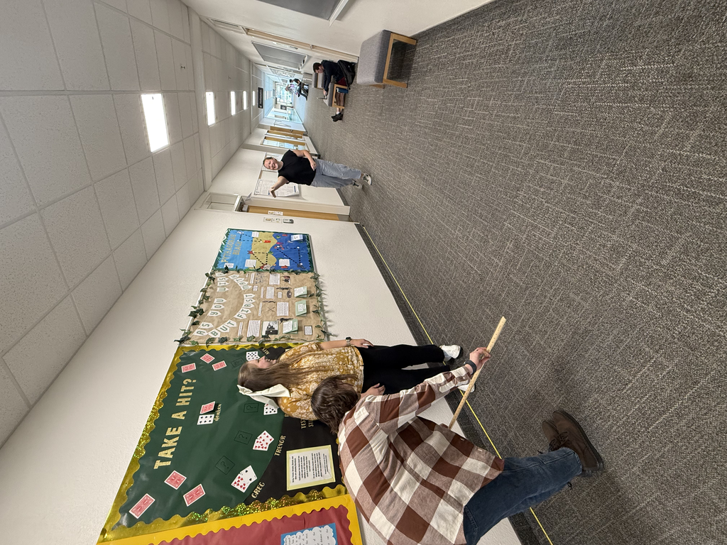

Paper Airplane Study

## Background

**Introduction & Methods**

I folded the planes, Cali threw them, and Stephanie recorded the distance measurements.

We folded 3 planes, 2 from the website Bro Amidan provided and 1 from my memory. That is the one factor we are testing, if different airplanes travel farther distances. We selected the 3 variations of plane based on the assumption that each one would be able to fly far over height or funny movements. Our response variable is distance.

Because we didn’t randomize, there is a possibility that some of the throws could be biased. The first throw compared to the last could have been thrown with less energy. Also viewing the performance of the planes throughout the data collection process could lead to bias. If I was throwing the planes I would be more biased because I like one plane more than the other.

I will be performing a Basic Factor 1 or a one-way anova test the average distance flown between 3 paper airplanes.

**Data**

In the data table I have included the name of the airplane used as well as the type of plane that it is. The 5th Grade Science plane was not based off of any type of plane found on the internet but is one that I created to show my 5th grade science class over 10 years ago. I had not forgotten how to make it, and there is no internet based reference on the actual type of paper airplane it is.

I have also converted the original data (collected in feet) to inches.

```r
library(dplyr)

papair <- papair %>%
  mutate(`distance (ft)` = `distance (ft)` * 12) %>%
  mutate(distance = round(`distance (ft)`, 2))

papair.aov <- papair %>%
  select(airplane, `type of plane`, distance, numbered_order, level_numbered_order)
```

```r
datatable(papair.aov, options=list(lengthMenu = c(5,10,30)))
```

|  | airplane | type of plane | distance | numbered_order | level_numbered_order |
| --- | --- | --- | --- | --- | --- |
| 1 | fifth_grade_science | idk | 195.12 | 1 | 1 |
| 2 | fifth_grade_science | idk | 276.84 | 4 | 2 |
| 3 | fifth_grade_science | idk | 313.56 | 7 | 3 |
| 4 | fifth_grade_science | idk | 232.68 | 10 | 4 |
| 5 | fifth_grade_science | idk | 261.72 | 13 | 5 |
| 6 | fifth_grade_science | idk | 338.52 | 16 | 6 |
| 7 | fifth_grade_science | idk | 209.28 | 18 | 7 |
| 8 | fifth_grade_science | idk | 218.52 | 21 | 8 |
| 9 | fifth_grade_science | idk | 338.64 | 24 | 9 |
| 10 | fifth_grade_science | idk | 303.48 | 27 | 10 |

[output cut: 20 more lines]

## Analysis

**Hypotheses**

**(1)**

$$H_0: \mu_\text{5th Grade Science} = \mu_\text{Sharki Boi} = \mu_\text{Nemo}$$

$$H_a: \text{The average distance of at least one paper air plane differs}$$

**(2)**

$$H_0: \alpha_\text{5th Grade Science} = \alpha_\text{Sharki Boi} = \alpha_\text{Nemo} = 0$$

$$H_a: \alpha \ne 0 \space\text{for at least one}\space\alpha_i$$
**Significance level is**

$$\alpha = 0.05$$

**ANOVA (BF[1])**

```r
papair.aov <- aov(distance ~ airplane, data=papair)
summary(papair.aov) %>%
  pander()
```

Analysis of Variance Model

|  | Df | Sum Sq | Mean Sq | F value | Pr(>F) |
| --- | --- | --- | --- | --- | --- |
| **airplane** | 2 | 145001 | 72501 | 33.44 | 4.939e-08 |
| **Residuals** | 27 | 58538 | 2168 | NA | NA |

The ANOVA test tells us that there is significance in comparing the 3 groups. We need to take a closer look to actually see that difference. We will run some graphs and then a post hoc test to see which groups are different and more different than the others.

**Graphs**

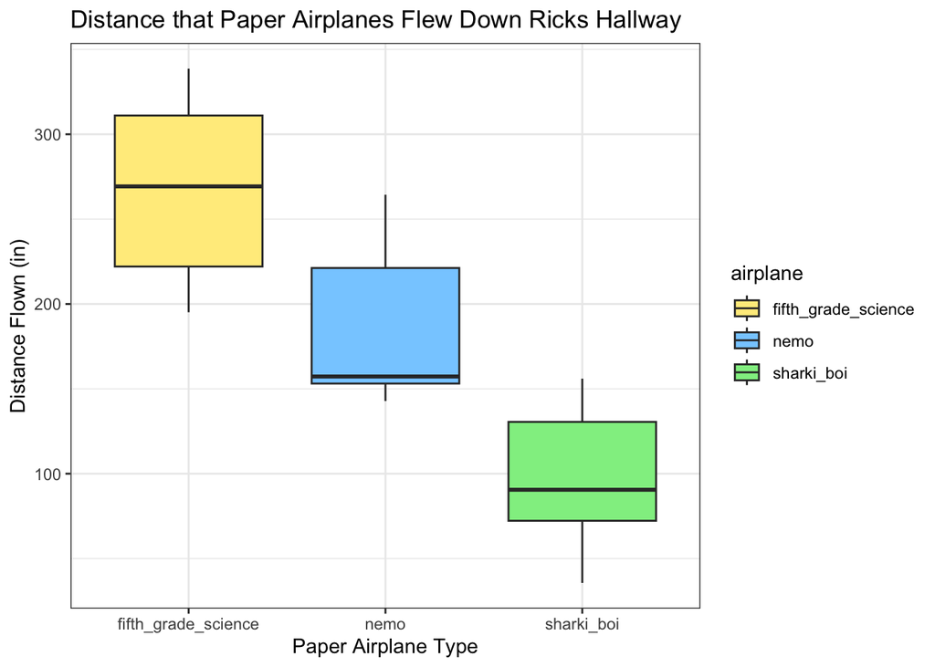

```r
## lets go a ggplot that's real sexy like

library(ggplot2)
library(dplyr)

ggplot(papair, aes(x=airplane, y=distance)) +
  geom_boxplot(aes(fill = airplane)) +
  theme_bw() +
  scale_fill_manual(values = c("lightgoldenrod1", "skyblue1", "lightgreen")) +
  labs(title = "Distance that Paper Airplanes Flew Down Ricks Hallway",
       fill = "airplane",
       x = "Paper Airplane Type",
       y = "Distance Flown (in)")
```

**Airplanes Numerical Summary**

```r
papair %>%
  group_by(airplane) %>%
  summarise(
    Average = mean(distance, na.rm = TRUE),
    Min = min(distance, na.rm = TRUE),
    Med = median(distance, na.rm = TRUE),
    Max = max(distance, na.rm = TRUE),
    StDev = sd(distance, na.rm = TRUE),
    SampleSize = n()
  ) %>%
  pander()
```

| airplane | Average | Min | Med | Max | StDev | SampleSize |
| --- | --- | --- | --- | --- | --- | --- |
| fifth_grade_science | 268.8 | 195.1 | 269.3 | 338.6 | 53.61 | 10 |
| nemo | 182.9 | 142.8 | 157.3 | 264.4 | 45.48 | 10 |
| sharki_boi | 98.54 | 35.64 | 90.54 | 156 | 39.52 | 10 |

Just looking at the fifth grade science we can see that the average is so much greater than the other two, even nemo is much greater than sharki boi.

**Diagnostics**

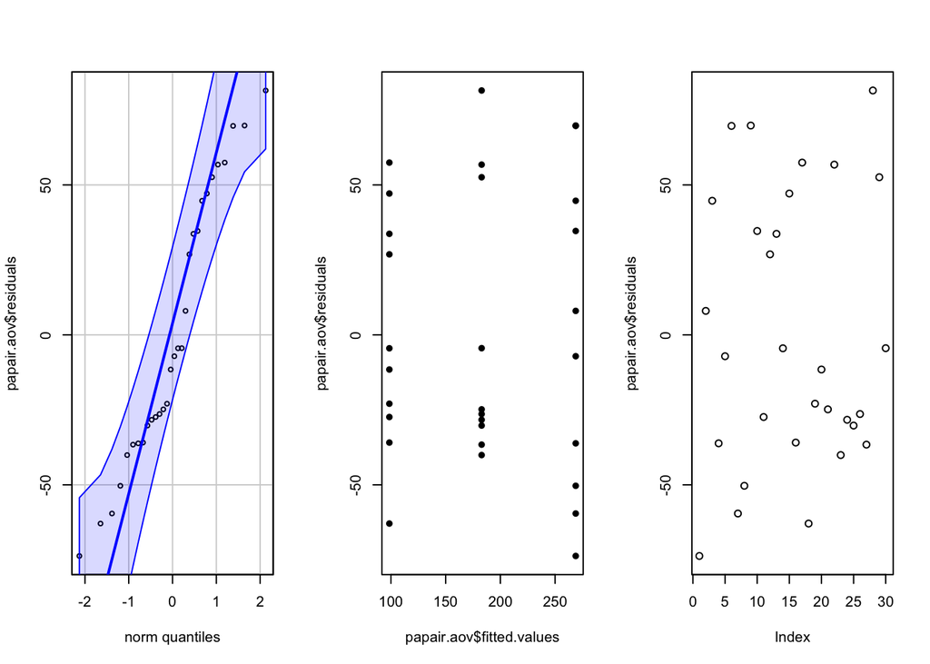

```r
par(mfrow=c(1,3))
qqPlot(papair.aov$residuals, id=FALSE)
plot(papair.aov$fitted.values, papair.aov$residuals, pch=16)
plot(papair.aov$residuals, id=FALSE)
```

The QQ plot shows the normality of the data within the bounds so we can assume that normality assumptions are met.

There is not a megaphone pattern in the residuals vs fitted plot, there is constant variance.

The 3rd plot depicts independence, there are no obvious trends in the data so we can conclude that independence requirements have been met.

We can conclude that all requirements have been met and that we can continue with the interpretation and post hoc tests of the experiment.

**Post Hoc Tests**

#### Individual Comparisons Between the 3 Airplanes

**Tukey**

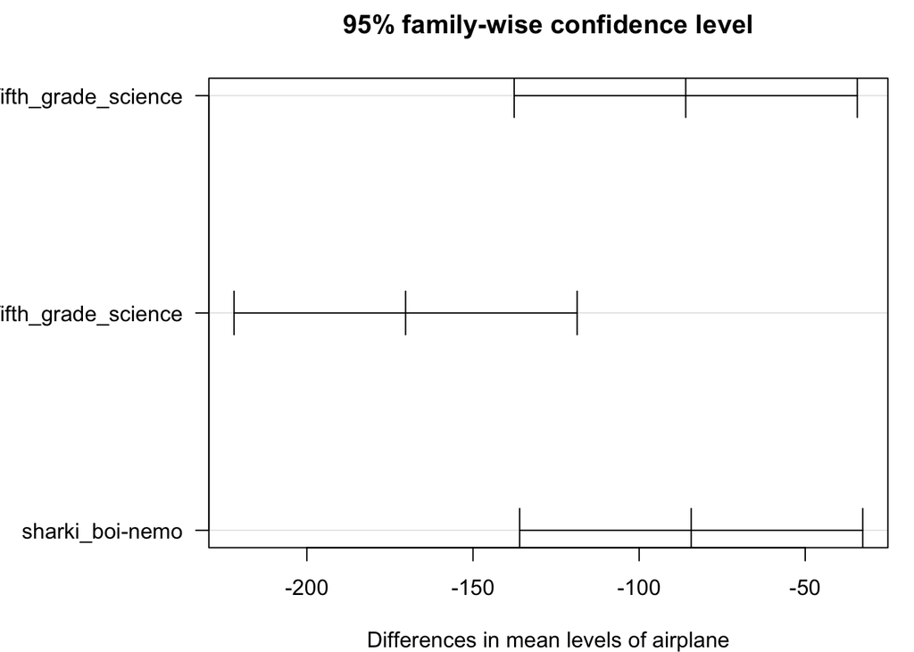

```r
tukey.aov.papair <- TukeyHSD(papair.aov, "airplane")
par(mar=c(4,8,3,1))
plot(tukey.aov.papair, las=1)
```

In this Tukey chart we see that none of the groups overlap on the 0 line so they are all different from eachother. I chose the Tukey test because I want to keep my Type 1 error low. I also want to see the confidence intervals.

#### Grouping Comparions

```r
library(emmeans)

air.means <- emmeans(papair.aov, "airplane", infer=c(TRUE,TRUE))

myContrasts <- contrast(air.means, list(`5thGradeSciencevsOthers`=c(1,-0.5,-0.5),
                                      `SharkiboivsOthers`=c(-0.5, 1, -0.5),
                                      `NemovsOthers`=c(-0.5, -0.5, 1)),adjust="scheffe")
myContrasts
```

```
 contrast                estimate SE df t.ratio p.value
 5thGradeSciencevsOthers  128.130 18 27   7.105 <0.0001
 SharkiboivsOthers         -0.822 18 27  -0.046  0.9990
 NemovsOthers            -127.308 18 27  -7.059 <0.0001

P value adjustment: scheffe method with rank 2
```

**Index**

(I ran all the different post hocs and didn’t want to straight up delete them)

**Fisher’s LSD**

```r
pa.fish <- pairwise.t.test(papair$distance, papair$airplane, "none")
pa.fish
```

```
    Pairwise comparisons using t tests with pooled SD

data:  papair$distance and papair$airplane

           fifth_grade_science nemo
nemo       0.00031             -
sharki_boi 8.8e-09             0.00039

P value adjustment method: none
```

**Bonferonni**

```r
pa.bon <- pairwise.t.test(papair$distance, papair$airplane, "bonferroni")
pa.bon
```

```
    Pairwise comparisons using t tests with pooled SD

data:  papair$distance and papair$airplane

           fifth_grade_science nemo
nemo       0.00094             -
sharki_boi 2.6e-08             0.00116

P value adjustment method: bonferroni
```

**Scheffé**

```r
library(agricolae)

scheffe.test(papair.aov, "airplane", console=TRUE)
```

```
Study: papair.aov ~ "airplane"

Scheffe Test for distance

Mean Square Error  : 2168.077

airplane,  means

                    distance      std  r       se    Min    Max    Q25    Q50
fifth_grade_science  268.836 53.60714 10 14.72439 195.12 338.64 222.06 269.28
nemo                 182.868 45.48429 10 14.72439 142.80 264.36 153.12 157.26
sharki_boi            98.544 39.51817 10 14.72439  35.64 156.00  72.27  90.54
                       Q75
fifth_grade_science 311.04
nemo                221.19
sharki_boi          130.53

Alpha: 0.05 ; DF Error: 27
Critical Value of F: 3.354131

Minimum Significant Difference: 53.93335

Means with the same letter are not significantly different.

                    distance groups
fifth_grade_science  268.836      a
nemo                 182.868      b
sharki_boi            98.544      c
```

## Interpretation

There is all the statistical significance in comparing `5th Grade Science` distance, `Nemo` distance, and `Sharki Boi` distance $\alpha$ > 4.94e-08.

It would be easy to conclude that the paper airplanes are not equal. That was clear to me in the stages of developing the planes. When we did our first test throw of each before taking measurements 5th grade science outdid the other two in distance and consistency.

If I was performing this test again I would fold the same plane and try different additional folds or even using different weighted paper.

: )

Back to top